# Visualizing Movie Ratings

Data Computing

A set of 100,000 ratings of movies by individuals was collected in the late 1990s by the *grouplens* research team at the University of Minnesota. The grouplens team provides the data directly at http://grouplens.org/datasets/movielens/100k/. These data were reformatted by for the *Data Computing* book. Downloaded them to your own computer with this statement:

```r
download.file("http://tiny.cc/dcf/MovieLens.rda",
              destfile = "MovieLens.rda")
```

You only need to download the data once. But each time you start a new R session you will need to `load()` the data to your R session.

Every time you *knit* a document, you are starting a new session just for the purpose of compiling that document.

`MovieLens.rda` contains three data tables:

- `Ratings` has the individual movie ratings and the time at which they were entered. It also includes an ID variable for both the user and the movie.
- `Movies` provides the name of the movie and information about genres.
- `Users` gives basic information about the person who made the rating.

Your task: Construct each of these graphics.

## Show the appeal of different genres to the different sexes

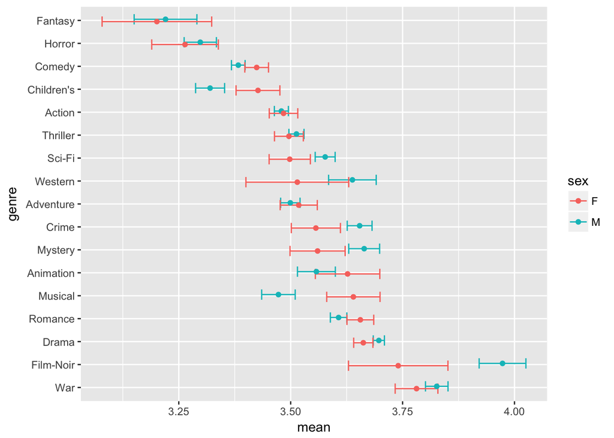

## Which genres are related?

Look at correlation between genres `cor()`.

Another possibility, look at the co-occurence, fraction of movie genre A that is also movie genre B.

```r
co_occurance <- function(genres){
  f <- function(x,y) {sum(x * y) / sum(x)}
  M <- matrix(0, nrow = ncol(genres), ncol = ncol(genres))
  for (first in 1:ncol(genres)) {
    for (second in 1:ncol(genres)) {
      M[first, second] <- f(genres[[first]], genres[[second]])
    }
  }
  M <- as.data.frame(M)
  names(M) <- names(genres)
  M$genre <- names(genres)
  M %>%
    tidyr::gather(key = genre2, value = co_occur, -genre)
}
```

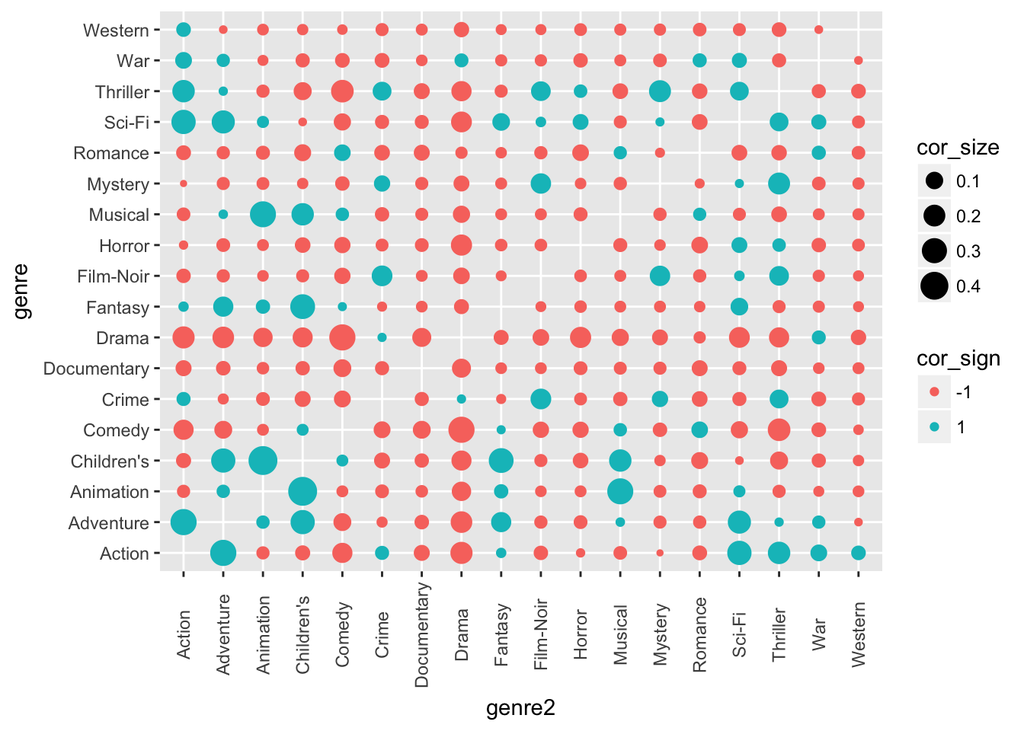

```r
Genres <- Movies[,6:23]
tmp <- cor(Genres) %>% as.data.frame(stringsAsFactors = FALSE)
tmp$genre <- row.names(tmp)
Genre_pairs <-
  tmp %>%
  gather(key = genre2, value = correlation, -genre) %>%
  filter(genre != genre2) %>%
  group_by(genre) %>%
  mutate(cor_sign = as.character(sign(correlation))) %>%
  mutate(cor_size = abs(correlation))
Genre_co_occur <- co_occurance(Genres) %>%
  filter(genre != genre2)
Genre_pairs %>%
  ggplot(aes(x = genre2, y = genre)) +
  geom_point(aes(size = cor_size, color = cor_sign)) +
  theme(axis.text.x  = element_text(angle=90, vjust=0.5))
```

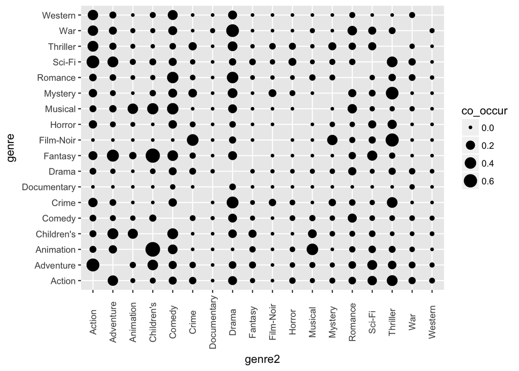

```r
Genre_co_occur %>%
  ggplot(aes(x = genre2, y = genre)) +
  geom_point(aes(size = co_occur)) +
  theme(axis.text.x  = element_text(angle=90, vjust=0.5))
```

As a network

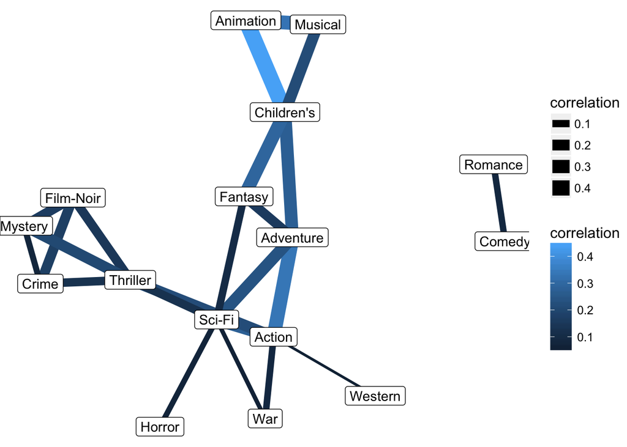

```r
library(igraph)
Keep_pairs <-
  Genre_pairs %>%
  filter(cor_size > 0.05, cor_sign == "1") %>%
  filter(genre > genre2)
Vertices <- Keep_pairs %>%
  edgesToVertices(from = genre, to = genre2)

Edges <-
  Vertices %>%
  edgesForPlotting(ID = ID, x, y, Edges = Keep_pairs, from = genre, to = genre2)
Vertices %>%
  ggplot(aes(x = x, y = y)) + geom_point()+
  geom_segment(data = Edges,
               aes(x = x, y = y, xend = xend, yend = yend,
                   color = correlation, size = correlation)) +
  theme_map() +
    geom_label(aes(label = ID), fill = "white")
```

And for co-occurances …

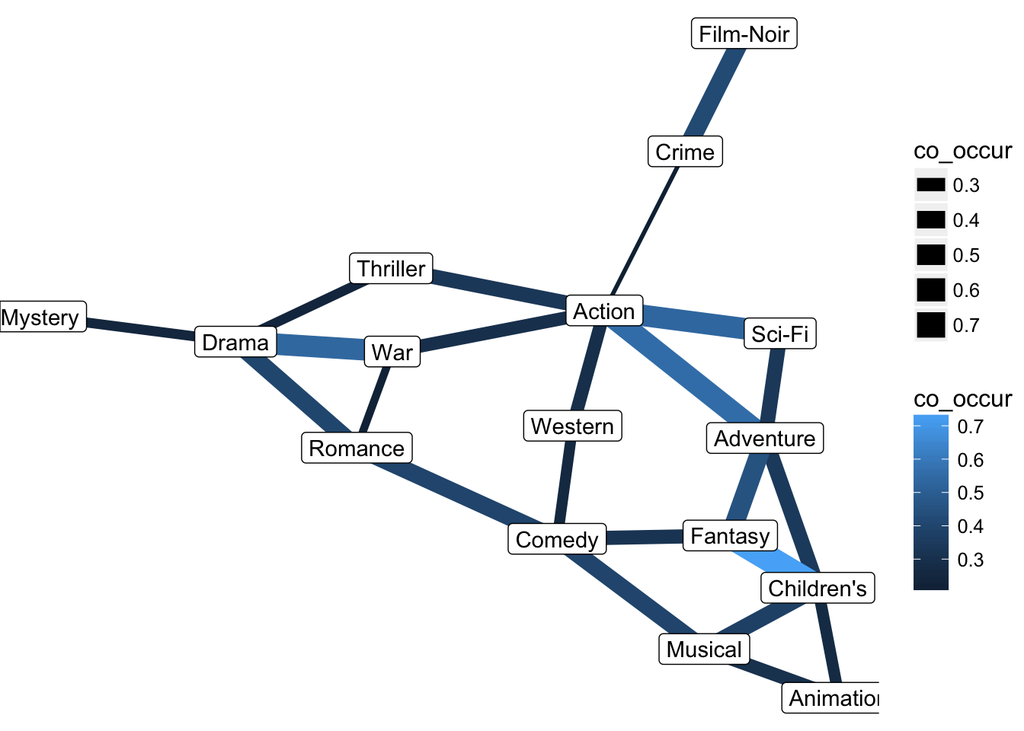

## Who are the reviewers?

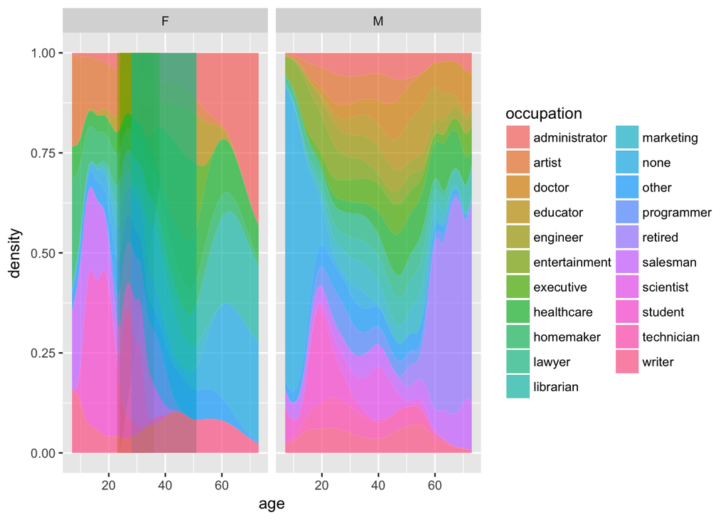

```r
Users %>%
  ggplot(aes(x = age)) +
  geom_density(aes(fill = occupation),
               color = NA, alpha = .7, position = "fill") +
  facet_wrap( ~ sex)
```

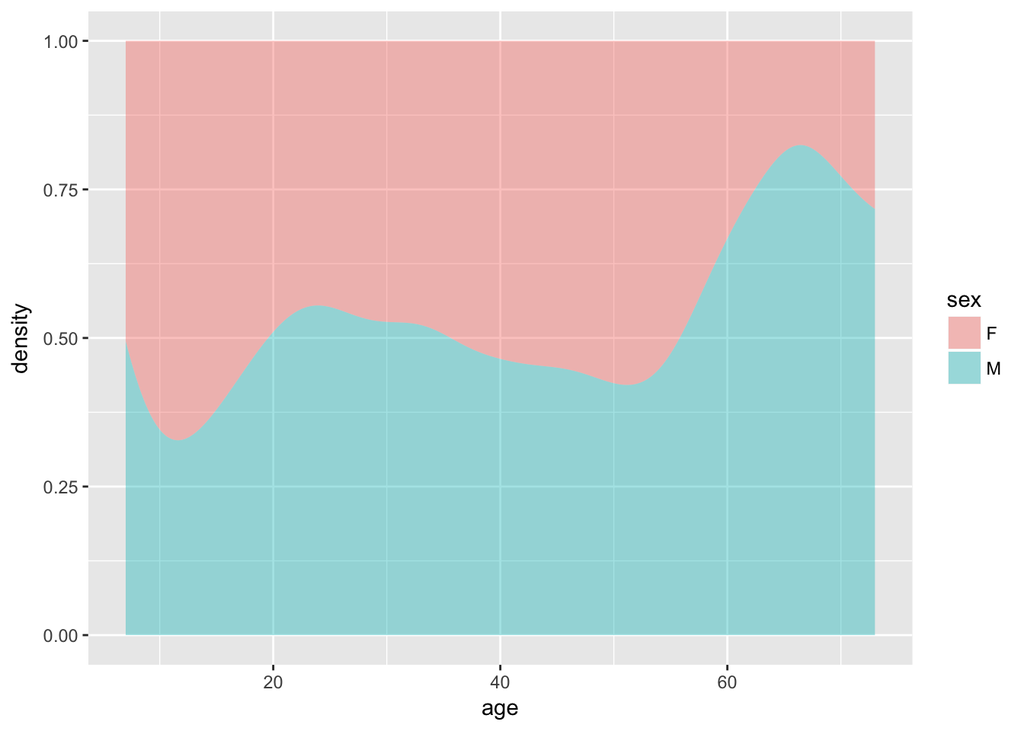

```r
Users %>%
  ggplot(aes(x = age)) +
  geom_density(aes(fill = sex),
               color = NA, alpha = .4, position = "fill")
```

```r
Users %>%
  group_by(occupation) %>%
  tally() %>%
  arrange(desc(n))
```

```
## # A tibble: 21 × 2
##       occupation     n
##            <chr> <int>
## 1        student   196
## 2          other   105
## 3       educator    95
## 4  administrator    79
## 5       engineer    67
## 6     programmer    66
## 7      librarian    51
## 8         writer    45
## 9      executive    32
## 10     scientist    31
## # ... with 11 more rows
```

## Ratings as people age

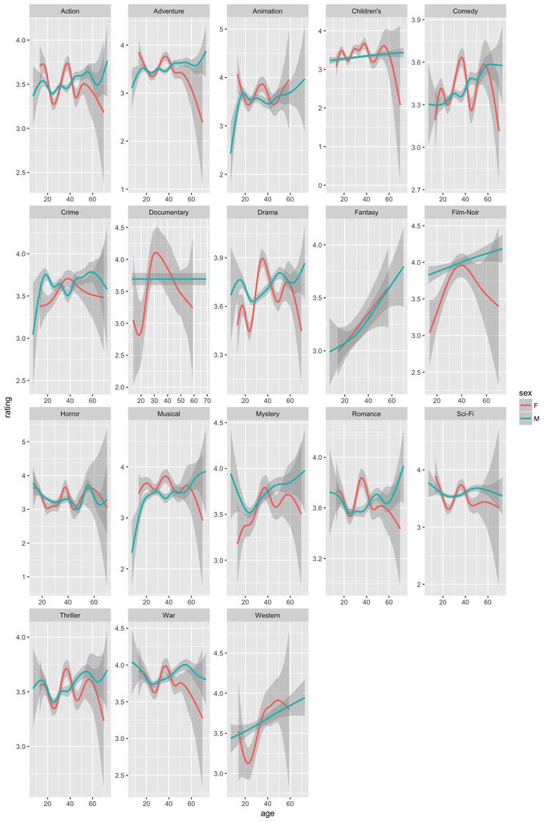

```r
All %>%
  filter( genre != "unknown") %>%
  ggplot(aes(x = age, color = sex, y = rating)) +
  geom_smooth() +
  facet_wrap( ~ genre, scales = "free")
```

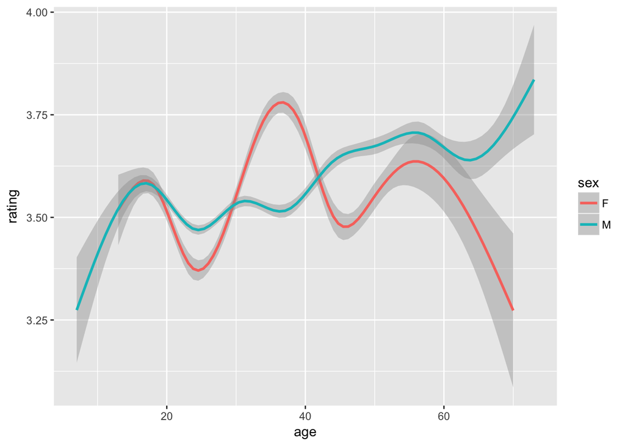

```r
All %>%
  ggplot(aes(x = age, color = sex, y = rating)) +
  geom_smooth()
```